# Design and Analysis of Experiments

David

2024-05-28

```r
# load packages
suppressMessages(
  {
    library(tidyverse)
    library(agricolae)
    library(report)
  }
)
```

# 1. Analysis of a Completely Randomised Design (CRD)

```r
## Comparing if different foodstuffs given to chicks significantly affect their weights

# Create a vector containing the weights of chicks
weights <- c(55,49,42,21,52,61,112,30,89,63,
             42,97,81,95,92,169,137,169,85,154)

# create another vector containing the various foodstuffs.
Foodstuffs <- c("A","A","A","A","A","B","B","B","B","B",
                "C","C","C","C","C","D","D","D","D","D")

# create a data frame of the weights and foodstuffs
Foodstuff_data <- data.frame(weights, Foodstuffs)

# fit a CRD model
CRD <- aov(weights ~ Foodstuffs, data = Foodstuff_data)

# model summary
summary(CRD)
```

```
##             Df Sum Sq Mean Sq F value   Pr(>F)
## Foodstuffs   3  26235    8745   12.11 0.000218 ***
## Residuals   16  11559     722
## ---
## Signif. codes:  0 '***' 0.001 '**' 0.01 '*' 0.05 '.' 0.1 ' ' 1
```

Since the p-value(0.000218) is much less than alpha(0.05), I reject Ho at 5% level of significance and conclude that the foodstuffs differ significantly with regards to increase in weight of chicks.

```r
# carry out post-hoc multiple comparison test using Least Significant Difference test
d <- LSD.test(CRD, "Foodstuffs", DFerror = 16, MSerror = 722,
              alpha = 0.05, console = TRUE)
```

```
##
## Study: CRD ~ "Foodstuffs"
##
## LSD t Test for weights
##
## Mean Square Error:  722.425
##
## Foodstuffs,  means and individual ( 95 %) CI
##
##   weights      std r       se       LCL       UCL Min Max Q25 Q50 Q75
## A    43.8 13.62718 5 12.02019  18.31833  69.28167  21  55  42  49  52
## B    71.0 31.02418 5 12.02019  45.51833  96.48167  30 112  61  63  89
## C    81.4 22.87575 5 12.02019  55.91833 106.88167  42  97  81  92  95
## D   142.8 34.90272 5 12.02019 117.31833 168.28167  85 169 137 154 169
##
## Alpha: 0.05 ; DF Error: 16
## Critical Value of t: 2.119905
##
## least Significant Difference: 36.03652
##
## Treatments with the same letter are not significantly different.
##
##   weights groups
## D   142.8      a
## C    81.4      b
## B    71.0     bc
## A    43.8      c
```

```r
# print LSD test results
d
```

```
## $statistics
##   MSerror Df  Mean       CV  t.value      LSD
##   722.425 16 84.75 31.71441 2.119905 36.03652
##
## $parameters
##         test p.ajusted     name.t ntr alpha
##   Fisher-LSD      none Foodstuffs   4  0.05
##
## $means
##   weights      std r       se       LCL       UCL Min Max Q25 Q50 Q75
## A    43.8 13.62718 5 12.02019  18.31833  69.28167  21  55  42  49  52
## B    71.0 31.02418 5 12.02019  45.51833  96.48167  30 112  61  63  89
## C    81.4 22.87575 5 12.02019  55.91833 106.88167  42  97  81  92  95
## D   142.8 34.90272 5 12.02019 117.31833 168.28167  85 169 137 154 169
##
## $comparison
## NULL
##
## $groups
##   weights groups
## D   142.8      a
## C    81.4      b
## B    71.0     bc
## A    43.8      c
##
## attr(,"class")
## [1] "group"
```

Foodstuffs C and B have almost the same effect, same as B and A. D is statistically different from the other foodstuffs. D has the highest mean weight, hence it is the best and is the one which should be fed to the chicks.

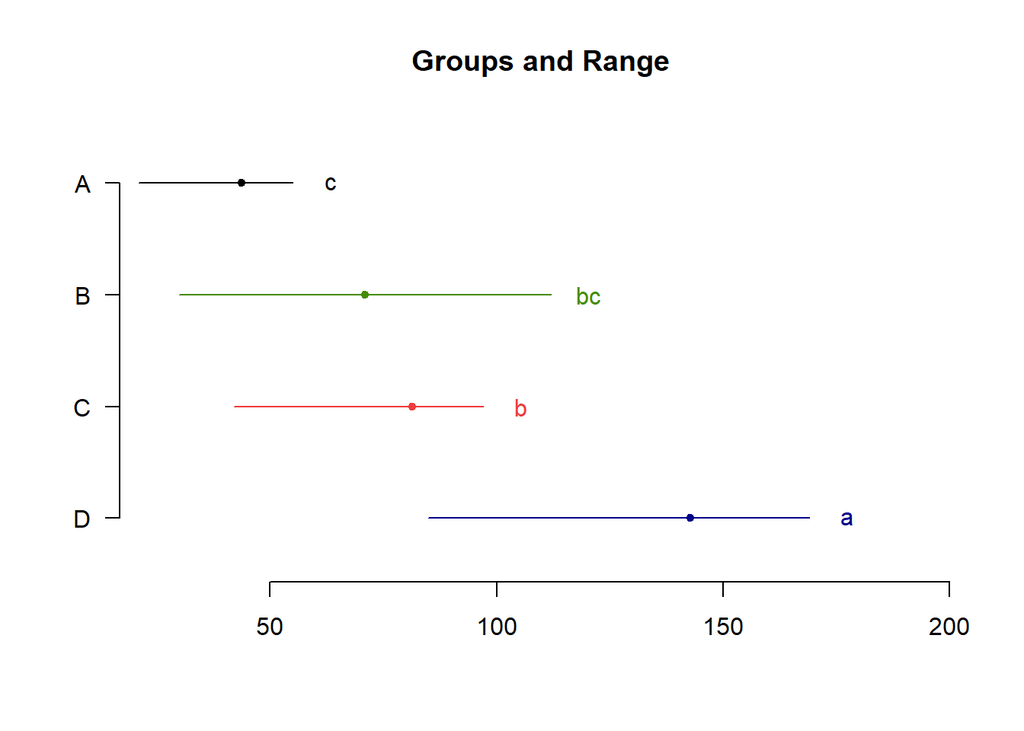

```r
# visualize the result
plot(d, las = 1, horiz = TRUE)
```

From this distribution, weights of chicks which were fed on foodstuff D varies differently from the others.

```r
# use Tukey's HSD test
HSD <- TukeyHSD(CRD, conf.level = .95)
HSD
```

```
##   Tukey multiple comparisons of means
##     95% family-wise confidence level
##
## Fit: aov(formula = weights ~ Foodstuffs, data = Foodstuff_data)
##
## $Foodstuffs
##     diff       lwr       upr     p adj
## B-A 27.2 -21.43481  75.83481 0.4061728
## C-A 37.6 -11.03481  86.23481 0.1621713
## D-A 99.0  50.36519 147.63481 0.0001380
## C-B 10.4 -38.23481  59.03481 0.9268359
## D-B 71.8  23.16519 120.43481 0.0032490
## D-C 61.4  12.76519 110.03481 0.0112771
```

Foodstuffs D and A are significantly different, same as D and B and also D and C, since their p-values are less than 0.05. I therefore conclude that foodstuff D is significantly different from C, B and A.

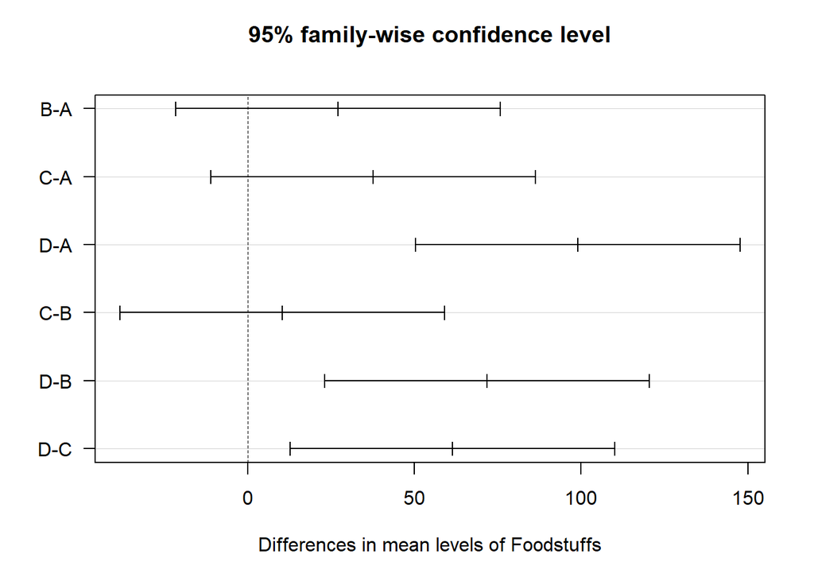

```r
# visualize the confidence intervals
plot(HSD, las = 1)
```

This distribution shows that B&A, C&A, C&B differ from D&A, D&B, D&C.

```r
## test whether the mean sales volume for 3 new menu items are all equal.

# first create the data
Sales <- c(31,31,45,21,42,32,27,28,29,18,36,17,24,31,46,48,46,40)
Items <- rep(c("Item1","Item2","Item3"), each = 6)
Item_sales <- data.frame(Sales, Items)

# view the first few observations of the Item_Sales data set
head(Item_sales)
```

```
##   Sales Items
## 1    31 Item1
## 2    31 Item1
## 3    45 Item1
## 4    21 Item1
## 5    42 Item1
## 6    32 Item1
```

```r
# fit ANOVA model
Items_model <- aov(Sales ~ Items, data = Item_sales)
# model summary
summary(Items_model)
```

```
##             Df Sum Sq Mean Sq F value Pr(>F)
## Items        2  538.8  269.39   3.663 0.0506 .
## Residuals   15 1103.0   73.53
## ---
## Signif. codes:  0 '***' 0.001 '**' 0.01 '*' 0.05 '.' 0.1 ' ' 1
```

Since the p-value(0.0506) is greater than alpha(0.05), I fail to reject Ho at 5% level of significance and conclude that the mean sales volume for the 3 new menu items are all equal. (Unless there’s a statistical power that says otherwise.)

```r
## Analysis of a CRD and use of Duncan's multiple range test and Student-Newman-Keuls(SNK) test for post hoc tests.

# load the sweet potato data set
data("sweetpotato")

# view the structure of the data set
glimpse(sweetpotato)
```

```
## Rows: 12
## Columns: 2
## $ virus <fct> cc, cc, cc, fc, fc, fc, ff, ff, ff, oo, oo, oo
## $ yield <dbl> 28.5, 21.7, 23.0, 14.9, 10.6, 13.1, 41.8, 39.2, 28.0, 38.2, 40.4…
```

The sweet potato dataset contains 12 observations of 2 variables. Virus is a categorical (factor) variable while yield is numeric.

```r
# clean the data

# check if the data has any missing values
map_dbl(sweetpotato, ~sum(which(is.na(.))))
```

```
## virus yield
##     0     0
```

```r
# check for duplicated observations
sum(duplicated(sweetpotato))
```

```
## [1] 0
```

The data is clean, has no missing values or duplicates.

```r
# carry out ANOVA to assess whether the viruses had the same effect on potato yield
sp_model <- aov(yield ~ virus, data = sweetpotato)
# model summary
summary(sp_model)
```

```
##             Df Sum Sq Mean Sq F value   Pr(>F)
## virus        3 1170.2   390.1   17.34 0.000733 ***
## Residuals    8  179.9    22.5
## ---
## Signif. codes:  0 '***' 0.001 '**' 0.01 '*' 0.05 '.' 0.1 ' ' 1
```

Since the p-value = 0.000733 is much less than alpha(0.05), I reject Ho at 5% significance level and conclude that the viruses have significantly different effects on potato yield.

```r
# carry out post-hoc multiple comparison test using Duncan's new multiple range test
dcun_test <- duncan.test(sp_model, "virus", alpha = 0.05,
                         group = TRUE, console = TRUE)
```

```
##
## Study: sp_model ~ "virus"
##
## Duncan's new multiple range test
## for yield
##
## Mean Square Error:  22.48917
##
## virus,  means
##
##       yield      std r       se  Min  Max   Q25  Q50   Q75
## cc 24.40000 3.609709 3 2.737953 21.7 28.5 22.35 23.0 25.75
## fc 12.86667 2.159475 3 2.737953 10.6 14.9 11.85 13.1 14.00
## ff 36.33333 7.333030 3 2.737953 28.0 41.8 33.60 39.2 40.50
## oo 36.90000 4.300000 3 2.737953 32.1 40.4 35.15 38.2 39.30
##
## Alpha: 0.05 ; DF Error: 8
##
## Critical Range
##        2        3        4
## 8.928965 9.304825 9.514910
##
## Means with the same letter are not significantly different.
##
##       yield groups
## oo 36.90000      a
## ff 36.33333      a
## cc 24.40000      b
## fc 12.86667      c
```

```r
dcun_test
```

```
## $statistics
##    MSerror Df   Mean      CV
##   22.48917  8 27.625 17.1666
##
## $parameters
##     test name.t ntr alpha
##   Duncan  virus   4  0.05
##
## $duncan
##      Table CriticalRange
## 2 3.261182      8.928965
## 3 3.398460      9.304825
## 4 3.475191      9.514910
##
## $means
##       yield      std r       se  Min  Max   Q25  Q50   Q75
## cc 24.40000 3.609709 3 2.737953 21.7 28.5 22.35 23.0 25.75
## fc 12.86667 2.159475 3 2.737953 10.6 14.9 11.85 13.1 14.00
## ff 36.33333 7.333030 3 2.737953 28.0 41.8 33.60 39.2 40.50
## oo 36.90000 4.300000 3 2.737953 32.1 40.4 35.15 38.2 39.30
##
## $comparison
## NULL
##
## $groups
##       yield groups
## oo 36.90000      a
## ff 36.33333      a
## cc 24.40000      b
## fc 12.86667      c
##
## attr(,"class")
## [1] "group"
```

Viruses oo and ff have almost the same effect on potato yield but their effects significantly differ from the effects of viruses cc and fc.

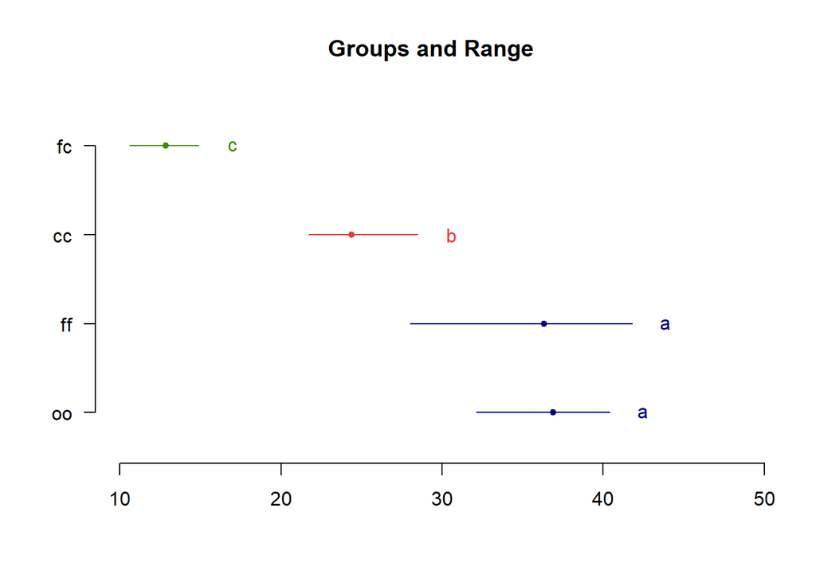

```r
# visualize the variations in yields
plot(dcun_test, horiz = TRUE, las = 1)
```

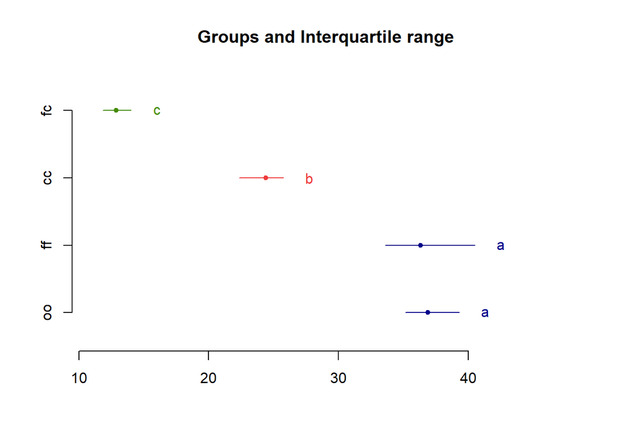

```r
plot(dcun_test, variation = "IQR", horiz = TRUE)
```

The variations and IQR pots also show that viruses oo and ff have almost the same effect on sweet potato yields, and differs significantly from viruses cc and fc.

```r
# use Student-Newman-Keuls(SNK) test
snk_test <-  SNK.test(sp_model, "virus", console = TRUE,
                      main =  "Yield of sweetpotato dealt with different virus")
```

```
##
## Study: Yield of sweetpotato dealt with different virus
##
## Student Newman Keuls Test
## for yield
##
## Mean Square Error:  22.48917
##
## virus,  means
##
##       yield      std r       se  Min  Max   Q25  Q50   Q75
## cc 24.40000 3.609709 3 2.737953 21.7 28.5 22.35 23.0 25.75
## fc 12.86667 2.159475 3 2.737953 10.6 14.9 11.85 13.1 14.00
## ff 36.33333 7.333030 3 2.737953 28.0 41.8 33.60 39.2 40.50
## oo 36.90000 4.300000 3 2.737953 32.1 40.4 35.15 38.2 39.30
##
## Alpha: 0.05 ; DF Error: 8
##
## Critical Range
##         2         3         4
##  8.928965 11.064170 12.399670
##
## Means with the same letter are not significantly different.
##
##       yield groups
## oo 36.90000      a
## ff 36.33333      a
## cc 24.40000      b
## fc 12.86667      c
```

```r
snk_test
```

```
## $statistics
##    MSerror Df   Mean      CV
##   22.48917  8 27.625 17.1666
##
## $parameters
##   test name.t ntr alpha
##    SNK  virus   4  0.05
##
## $snk
##      Table CriticalRange
## 2 3.261182      8.928965
## 3 4.041036     11.064170
## 4 4.528810     12.399670
##
## $means
##       yield      std r       se  Min  Max   Q25  Q50   Q75
## cc 24.40000 3.609709 3 2.737953 21.7 28.5 22.35 23.0 25.75
## fc 12.86667 2.159475 3 2.737953 10.6 14.9 11.85 13.1 14.00
## ff 36.33333 7.333030 3 2.737953 28.0 41.8 33.60 39.2 40.50
## oo 36.90000 4.300000 3 2.737953 32.1 40.4 35.15 38.2 39.30
##
## $comparison
## NULL
##
## $groups
##       yield groups
## oo 36.90000      a
## ff 36.33333      a
## cc 24.40000      b
## fc 12.86667      c
##
## attr(,"class")
## [1] "group"
```

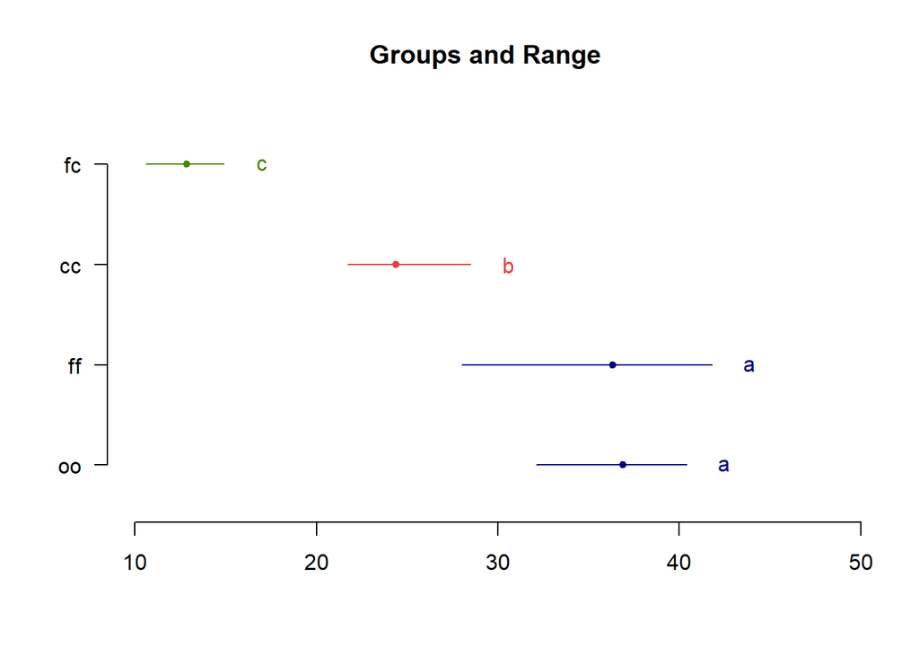

```r
# visualize SNK.test results
plot(snk_test, las = 1, horiz = TRUE)
```

SNK test gives the same results as Duncan’s multiple range test.

# 2. Analysis of Randomised Block Design (RBD)

```r
## Given data on the quantity of fertilizer used during planting and the amount of water sprayed for the crops. Test if there's significant difference in yield produced

# create a vector containing fertilizer quantities
Fertilizer <- c("low","high","low","high")
# create a vector containing quantities of water applied
Irrigation <- rep(c("low","high"), each = 2)
# create a vector containing yield quantities
Yield <- c(20,40,30,52)

# create a data frame for the yields, fertilizer and irrigation
YieldData <- data.frame(Yield, Fertilizer, Irrigation)
```

```r
# fit the model
YieldModel <- aov(Yield ~ Fertilizer + Irrigation, data = YieldData)
# model summary
summary(YieldModel)
```

```
##             Df Sum Sq Mean Sq F value Pr(>F)
## Fertilizer   1    441     441     441 0.0303 *
## Irrigation   1    121     121     121 0.0577 .
## Residuals    1      1       1
## ---
## Signif. codes:  0 '***' 0.001 '**' 0.01 '*' 0.05 '.' 0.1 ' ' 1
```

- The Fertilizer quantity applied had a significant effect on crop yield (p-value < 0.05)
- Irrigation (quantity of water applied) on the other hand had no significant effect on crop yield (p-value > 0.05)

I used the irrigation quantity as my blocks. I won’t carry post-hoc analysis for this example.

```r
## Another example on RBD

# first create the dataset

# create a vector of values
Values <- c(24.7,20.6,27.7,16.2,16.2,24.9,27.3,28.8,22.7,15.0,17.0,22.5,
            38.5,39.5,36.8,19.6,15.4,26.3,28.5,31.0,34.9,14.1,17.7,22.6)

# create a vector of treatments
Treatments <- rep(c("T1","T2","T3","T4","T5","T6"), 4)
# create a vector of blocks
Blocks <- rep(c("B1","B2","B3","B4"), each = 6)

# combine the vectors into a data frame
RBD_data <- data.frame(Values, Treatments, Blocks)
# view the first few obs
head(RBD_data)
```

```
##   Values Treatments Blocks
## 1   24.7         T1     B1
## 2   20.6         T2     B1
## 3   27.7         T3     B1
## 4   16.2         T4     B1
## 5   16.2         T5     B1
## 6   24.9         T6     B1
```

```r
# fit the model
RBD <- aov(Values ~ Treatments + Blocks, data = RBD_data)
# model summary
summary(RBD)
```

```
##             Df Sum Sq Mean Sq F value   Pr(>F)
## Treatments   5  901.2  180.24  11.773 9.28e-05 ***
## Blocks       3  219.4   73.14   4.778   0.0157 *
## Residuals   15  229.6   15.31
## ---
## Signif. codes:  0 '***' 0.001 '**' 0.01 '*' 0.05 '.' 0.1 ' ' 1
```

- Since the p-value associated with treatments is much less than alpha(0.05), I reject Ho at 5% significance level and conclude that the treatments differ significantly.
- Since the p-value associated with blocks is also less than beta(0.05), I reject Ho at 5% significance level and conclude that the blocks differ significantly. This makes sense because in a Randomized Block Design, the blocks should be homogeneous within themselves but heterogeneous among themselves.

```r
# carry out LSD-test on treatments
d2 <- LSD.test(RBD, "Treatments", DFerror = 15, MSerror = 15.31,
               alpha = 0.05, group = TRUE, console = TRUE)
```

```
##
## Study: RBD ~ "Treatments"
##
## LSD t Test for Values
##
## Mean Square Error:  15.30931
##
## Treatments,  means and individual ( 95 %) CI
##
##    Values       std r       se      LCL      UCL  Min  Max    Q25   Q50    Q75
## T1 29.750 6.0451082 4 1.956355 25.58013 33.91987 24.7 38.5 26.650 27.90 31.000
## T2 29.975 7.7684726 4 1.956355 25.80513 34.14487 20.6 39.5 26.750 29.90 33.125
## T3 30.525 6.5250160 4 1.956355 26.35513 34.69487 22.7 36.8 26.450 31.30 35.375
## T4 16.225 2.4088379 4 1.956355 12.05513 20.39487 14.1 19.6 14.775 15.60 17.050
## T5 16.575 0.9945686 4 1.956355 12.40513 20.74487 15.4 17.7 16.000 16.60 17.175
## T6 24.075 1.8518009 4 1.956355 19.90513 28.24487 22.5 26.3 22.575 23.75 25.250
##
## Alpha: 0.05 ; DF Error: 15
## Critical Value of t: 2.13145
##
## least Significant Difference: 5.897091
##
## Treatments with the same letter are not significantly different.
##
##    Values groups
## T3 30.525      a
## T2 29.975      a
## T1 29.750     ab
## T6 24.075      b
## T5 16.575      c
## T4 16.225      c
```

```r
# view LSD-test results
d2
```

```
## $statistics
##    MSerror Df     Mean       CV t.value      LSD
##   15.30931 15 24.52083 15.95668 2.13145 5.897091
##
## $parameters
##         test p.ajusted     name.t ntr alpha
##   Fisher-LSD      none Treatments   6  0.05
##
## $means
##    Values       std r       se      LCL      UCL  Min  Max    Q25   Q50    Q75
## T1 29.750 6.0451082 4 1.956355 25.58013 33.91987 24.7 38.5 26.650 27.90 31.000
## T2 29.975 7.7684726 4 1.956355 25.80513 34.14487 20.6 39.5 26.750 29.90 33.125
## T3 30.525 6.5250160 4 1.956355 26.35513 34.69487 22.7 36.8 26.450 31.30 35.375
## T4 16.225 2.4088379 4 1.956355 12.05513 20.39487 14.1 19.6 14.775 15.60 17.050
## T5 16.575 0.9945686 4 1.956355 12.40513 20.74487 15.4 17.7 16.000 16.60 17.175
## T6 24.075 1.8518009 4 1.956355 19.90513 28.24487 22.5 26.3 22.575 23.75 25.250
##
## $comparison
## NULL
##
## $groups
##    Values groups
## T3 30.525      a
## T2 29.975      a
## T1 29.750     ab
## T6 24.075      b
## T5 16.575      c
## T4 16.225      c
##
## attr(,"class")
## [1] "group"
```

# 3. Analysis of Latin Square Design (LSD)

```r
## Given productivity data based on 5 different kinds of fertilizer, 5 kinds of tillage, and 5 kinds of seeds. Test if there are significant differences between fertilizer, tillage and seed types, with regards to the quantity of yield produced. The data is organized in a Latin square design.

# First create a data frame with all the attributes
Fertilizer <- rep(c("F1","F2","F3","F4","F5"),5)

Tillage <- rep(c("A","B","C","D","E"), each = 5)

Seed <- c("a","e","c","b","d","c","b","a","d","e",
          "b","c","d","e","a","d","a","e","c","b",
          "e","d","b","a","c")

Yield <- c(42,45,41,56,47,47,54,46,52,49,55,52,57,
           49,45,51,44,47,50,54,44,50,48,43,46)

Production_data <- data.frame(Tillage, Fertilizer, Seed, Yield)
```

```r
# create matrices representing the attributes

# Treatments
matrix(Production_data$Tillage,5,5)
```

```
##      [,1] [,2] [,3] [,4] [,5]
## [1,] "A"  "B"  "C"  "D"  "E"
## [2,] "A"  "B"  "C"  "D"  "E"
## [3,] "A"  "B"  "C"  "D"  "E"
## [4,] "A"  "B"  "C"  "D"  "E"
## [5,] "A"  "B"  "C"  "D"  "E"
```

```r
# Fertilizer types
matrix(Production_data$Fertilizer,5,5)
```

```
##      [,1] [,2] [,3] [,4] [,5]
## [1,] "F1" "F1" "F1" "F1" "F1"
## [2,] "F2" "F2" "F2" "F2" "F2"
## [3,] "F3" "F3" "F3" "F3" "F3"
## [4,] "F4" "F4" "F4" "F4" "F4"
## [5,] "F5" "F5" "F5" "F5" "F5"
```

```r
# Seed types
matrix(Production_data$Seed,5,5)
```

```
##      [,1] [,2] [,3] [,4] [,5]
## [1,] "a"  "c"  "b"  "d"  "e"
## [2,] "e"  "b"  "c"  "a"  "d"
## [3,] "c"  "a"  "d"  "e"  "b"
## [4,] "b"  "d"  "e"  "c"  "a"
## [5,] "d"  "e"  "a"  "b"  "c"
```

```r
# Yields
matrix(Production_data$Yield,5,5)
```

```
##      [,1] [,2] [,3] [,4] [,5]
## [1,]   42   47   55   51   44
## [2,]   45   54   52   44   50
## [3,]   41   46   57   47   48
## [4,]   56   52   49   50   43
## [5,]   47   49   45   54   46
```

```r
# carry out anova
Latin_sq_design <- aov(Yield ~ Tillage + Fertilizer + Seed, data = Production_data)
# model summary
summary(Latin_sq_design)
```

```
##             Df Sum Sq Mean Sq F value   Pr(>F)
## Tillage      4 109.36   27.34   4.906 0.014105 *
## Fertilizer   4  17.76    4.44   0.797 0.549839
## Seed         4 286.16   71.54  12.836 0.000271 ***
## Residuals   12  66.88    5.57
## ---
## Signif. codes:  0 '***' 0.001 '**' 0.01 '*' 0.05 '.' 0.1 ' ' 1
```

- Since the p-value associated with tillage is less than 0.05, I reject Ho at 5% level of significance and conclude that the different kinds of tillage used were significantly different with regards to production yields.
- Since the p-value associated with Fertilizers is highly greater than 0.05, I fail to reject Ho at 5% level of significance and conclude that the fertilizers do not differ significantly with regards to production yields.
- Since the p-value associated with Seeds is much less than 0.05, I reject Ho at 5% significance level and conclude that the seed types differ significantly with regards to production yields.

```r
# carry out post-hoc multiple comparison test on Tillage and seed types using Tukey's HSD test
TukeyHSD(Latin_sq_design, conf.level=.95)
```

```
##   Tukey multiple comparisons of means
##     95% family-wise confidence level
##
## Fit: aov(formula = Yield ~ Tillage + Fertilizer + Seed, data = Production_data)
##
## $Tillage
##              diff         lwr        upr     p adj
## B-A  3.400000e+00  -1.3591399  8.1591399 0.2175142
## C-A  5.400000e+00   0.6408601 10.1591399 0.0239813
## D-A  3.000000e+00  -1.7591399  7.7591399 0.3181622
## E-A -2.131628e-14  -4.7591399  4.7591399 1.0000000
## C-B  2.000000e+00  -2.7591399  6.7591399 0.6738074
## D-B -4.000000e-01  -5.1591399  4.3591399 0.9986976
## E-B -3.400000e+00  -8.1591399  1.3591399 0.2175142
## D-C -2.400000e+00  -7.1591399  2.3591399 0.5200518
## E-C -5.400000e+00 -10.1591399 -0.6408601 0.0239813
## E-D -3.000000e+00  -7.7591399  1.7591399 0.3181622
##
## $Fertilizer
##                diff      lwr     upr     p adj
## F2-F1  1.200000e+00 -3.55914 5.95914 0.9245185
## F3-F1 -2.131628e-14 -4.75914 4.75914 1.0000000
## F4-F1  2.200000e+00 -2.55914 6.95914 0.5965545
## F5-F1  4.000000e-01 -4.35914 5.15914 0.9986976
## F3-F2 -1.200000e+00 -5.95914 3.55914 0.9245185
## F4-F2  1.000000e+00 -3.75914 5.75914 0.9593153
## F5-F2 -8.000000e-01 -5.55914 3.95914 0.9816941
## F4-F3  2.200000e+00 -2.55914 6.95914 0.5965545
## F5-F3  4.000000e-01 -4.35914 5.15914 0.9986976
## F5-F4 -1.800000e+00 -6.55914 2.95914 0.7485642
##
## $Seed
##     diff         lwr        upr     p adj
## b-a  9.4   4.6408601 14.1591399 0.0003129
## c-a  3.2  -1.5591399  7.9591399 0.2642252
## d-a  7.4   2.6408601 12.1591399 0.0025012
## e-a  2.8  -1.9591399  7.5591399 0.3792691
## c-b -6.2 -10.9591399 -1.4408601 0.0095740
## d-b -2.0  -6.7591399  2.7591399 0.6738074
## e-b -6.6 -11.3591399 -1.8408601 0.0060822
## d-c  4.2  -0.5591399  8.9591399 0.0936276
## e-c -0.4  -5.1591399  4.3591399 0.9986976
## e-d -4.6  -9.3591399  0.1591399 0.0598894
```

- Based on the Tukey’s HSD test:
  - Tillage C&A, E&C differ significantly.
  - Seed types b&a, d&a, c&b, e&b also differ significantly.
  - All the fertilizer types had almost the same effect with regards to the quantity of yields produced.

# 4. Analysis of Factorial Designs (Designs with main and interaction effects)

```r
# Load the Tooth Growth data
data("ToothGrowth")

# View structure of the data
ToothGrowth |> glimpse()
```

```
## Rows: 60
## Columns: 3
## $ len  <dbl> 4.2, 11.5, 7.3, 5.8, 6.4, 10.0, 11.2, 11.2, 5.2, 7.0, 16.5, 16.5,…
## $ supp <fct> VC, VC, VC, VC, VC, VC, VC, VC, VC, VC, VC, VC, VC, VC, VC, VC, V…
## $ dose <dbl> 0.5, 0.5, 0.5, 0.5, 0.5, 0.5, 0.5, 0.5, 0.5, 0.5, 1.0, 1.0, 1.0, …
```

The data has 60 observations of 3 variables. Length and dose are numeric while supplement is a factor with two levels.

```r
# Factor the variable dose
ToothGrowth[["dose"]] <- factor(ToothGrowth[["dose"]],
                                levels = c(0.5, 1, 2),
                                labels = c("low","medium","high") )
```

```r
# Quickly explore the data
ToothGrowth |> skimr::skim()
```

Data summary

| Name | ToothGrowth |
| --- | --- |
| Number of rows | 60 |
| Number of columns | 3 |
| _______________________ |  |
| Column type frequency: |  |
| factor | 2 |
| numeric | 1 |
| ________________________ |  |
| Group variables | None |

**Variable type: factor**

| skim_variable | n_missing | complete_rate | ordered | n_unique | top_counts |
| --- | --- | --- | --- | --- | --- |
| supp | 0 | 1 | FALSE | 2 | OJ: 30, VC: 30 |
| dose | 0 | 1 | FALSE | 3 | low: 20, med: 20, hig: 20 |

**Variable type: numeric**

| skim_variable | n_missing | complete_rate | mean | sd | p0 | p25 | p50 | p75 | p100 | hist |
| --- | --- | --- | --- | --- | --- | --- | --- | --- | --- | --- |
| len | 0 | 1 | 18.81 | 7.65 | 4.2 | 13.07 | 19.25 | 25.27 | 33.9 | ▅▃▅▇▂ |

There are no missing values in the data. The variable supplement has 2 levels while dosage has 3 levels. The factor variables are evenly distributed. Tooth length has a mean and standard deviation of 18.81 and 7.65 respectively.

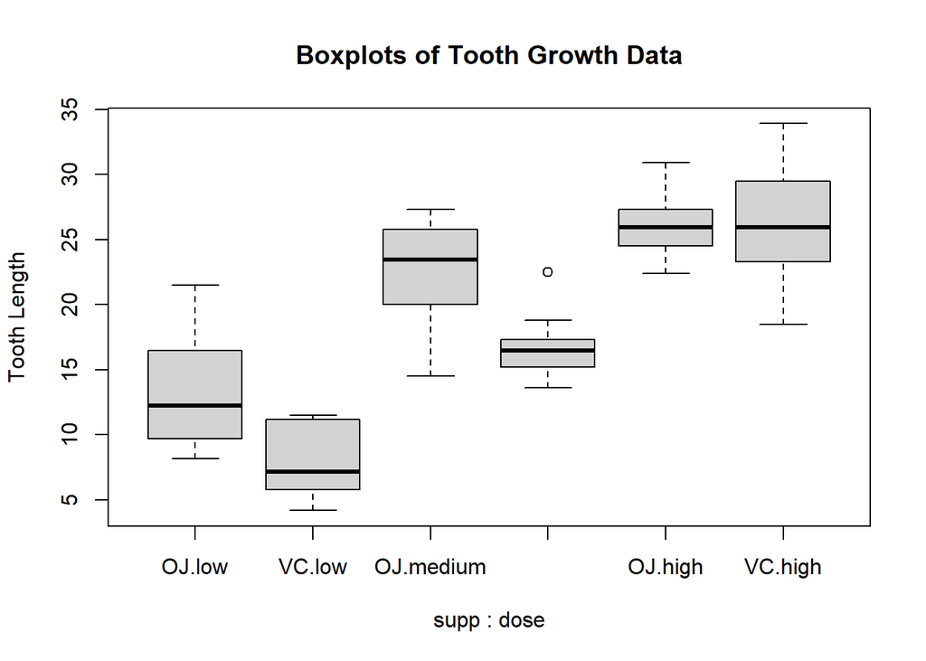

```r
# Visualize the distribution of tooth length, characterized by supplement and dosage
boxplot(len ~ supp * dose, data = ToothGrowth,
        ylab="Tooth Length",
        main="Boxplots of Tooth Growth Data")
```

Generally, there seems to be differences in the means of tooth length based on the dosage and supplement types, except for the supplement given at high dosage.

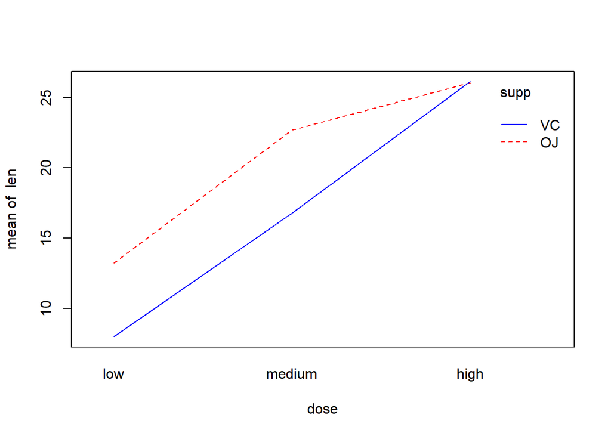

```r
# interaction plot
with(ToothGrowth, interaction.plot(x.factor = dose,
                                   trace.factor = supp, response = len,
                                   col = c("red","blue")))
```

- There seems to be no difference between supplements at high dose.
- There seems to be a main effect of dose i.e higher dose results in higher tooth length
- Also, there seems to be a main effect of supplement i.e there is a difference in tooth growth between VC and OJ supplements at low and medium dosage.

```r
# fit ANOVA Model
ToothGrowth_model <- aov(len ~ supp * dose, data = ToothGrowth)
summary(ToothGrowth_model)
```

```
##             Df Sum Sq Mean Sq F value   Pr(>F)
## supp         1  205.4   205.4  15.572 0.000231 ***
## dose         2 2426.4  1213.2  92.000  < 2e-16 ***
## supp:dose    2  108.3    54.2   4.107 0.021860 *
## Residuals   54  712.1    13.2
## ---
## Signif. codes:  0 '***' 0.001 '**' 0.01 '*' 0.05 '.' 0.1 ' ' 1
```

The main effects of supplement and dosage are all significant, same as the interaction effect between supplement and dosage. (p < 0.05)

```r
# carry out post-hoc analysis using Tukey's HSD test
TukeyHSD(ToothGrowth_model)
```

```
##   Tukey multiple comparisons of means
##     95% family-wise confidence level
##
## Fit: aov(formula = len ~ supp * dose, data = ToothGrowth)
##
## $supp
##       diff       lwr       upr     p adj
## VC-OJ -3.7 -5.579828 -1.820172 0.0002312
##
## $dose
##               diff       lwr       upr   p adj
## medium-low   9.130  6.362488 11.897512 0.0e+00
## high-low    15.495 12.727488 18.262512 0.0e+00
## high-medium  6.365  3.597488  9.132512 2.7e-06
##
## $`supp:dose`
##                      diff        lwr        upr     p adj
## VC:low-OJ:low       -5.25 -10.048124 -0.4518762 0.0242521
## OJ:medium-OJ:low     9.47   4.671876 14.2681238 0.0000046
## VC:medium-OJ:low     3.54  -1.258124  8.3381238 0.2640208
## OJ:high-OJ:low      12.83   8.031876 17.6281238 0.0000000
## VC:high-OJ:low      12.91   8.111876 17.7081238 0.0000000
## OJ:medium-VC:low    14.72   9.921876 19.5181238 0.0000000
## VC:medium-VC:low     8.79   3.991876 13.5881238 0.0000210
## OJ:high-VC:low      18.08  13.281876 22.8781238 0.0000000
## VC:high-VC:low      18.16  13.361876 22.9581238 0.0000000
## VC:medium-OJ:medium -5.93 -10.728124 -1.1318762 0.0073930
## OJ:high-OJ:medium    3.36  -1.438124  8.1581238 0.3187361
## VC:high-OJ:medium    3.44  -1.358124  8.2381238 0.2936430
## OJ:high-VC:medium    9.29   4.491876 14.0881238 0.0000069
## VC:high-VC:medium    9.37   4.571876 14.1681238 0.0000058
## VC:high-OJ:high      0.08  -4.718124  4.8781238 1.0000000
```

- All the simple main effects are statistically significant (p-value < 0.05)
- All the interaction effects are statistically significant, except (VC:medium-OJ:low), (OJ:high-OJ:medium) , (VC:high-OJ:medium) and (VC:high-OJ:high).

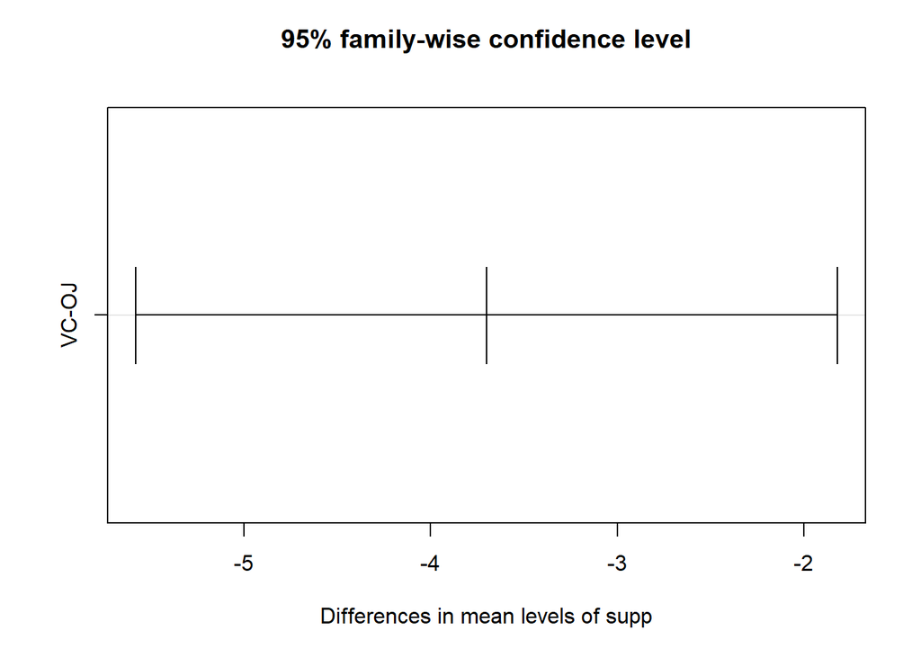

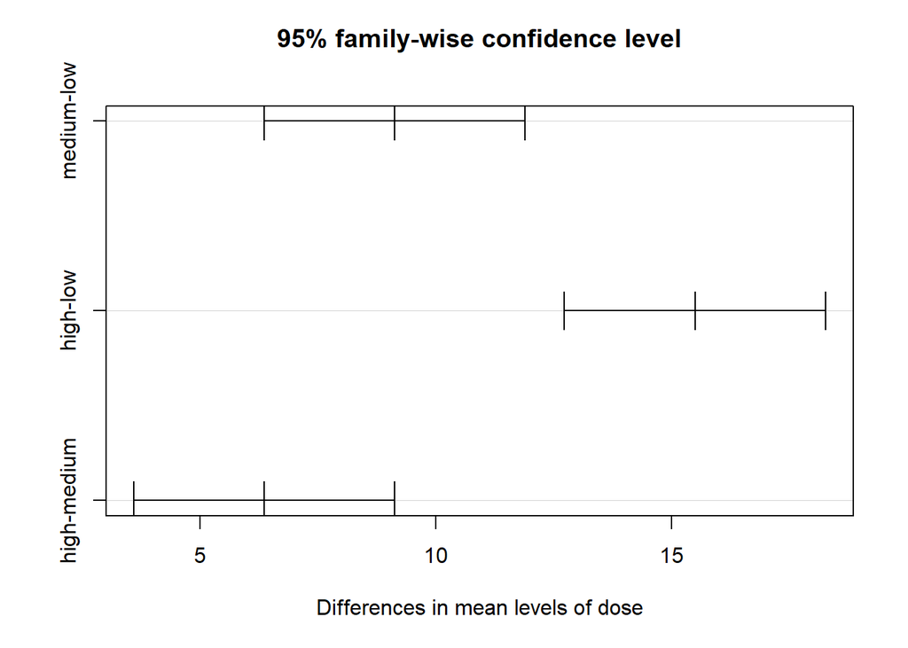

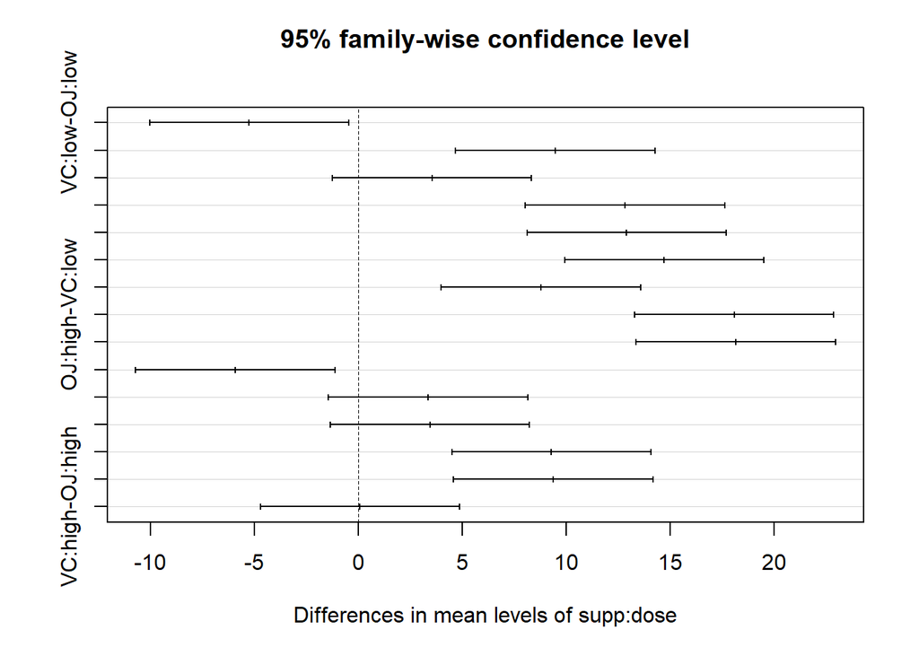

```r
# visualize the difference in means and Confidence Intervals
plot(TukeyHSD(ToothGrowth_model))
```

```r
## Assessing the effects of material type and temperature on battery life

# creating the data

# create a vector of values for battery life
Values <- c(130,74,155,180,34,80,40,75,20,82,70,58,150,159,
            188,126,136,106,122,115,25,58,70,45,138,168,110,
            160,174,150,120,139,96,82,104,60)

# create a vector containing the different material types
Material_type <- rep(c("1","2","3"), each = 12)

# create a vector containing the different temperature levels
Temp <- rep(c("15","15","15","15","70","70","70","70","125","125",
              "125","125"),3)

# combine the vectors into a data frame
Battery_data <- data.frame(Values, Material_type, Temp)
```

```r
# fit the model
BattModel <- aov(Values ~ Material_type*Temp, data = Battery_data)
# model summary
summary(BattModel)
```

```
##                    Df Sum Sq Mean Sq F value   Pr(>F)
## Material_type       2  10684    5342   7.911  0.00198 **
## Temp                2  39119   19559  28.968 1.91e-07 ***
## Material_type:Temp  4   9614    2403   3.560  0.01861 *
## Residuals          27  18231     675
## ---
## Signif. codes:  0 '***' 0.001 '**' 0.01 '*' 0.05 '.' 0.1 ' ' 1
```

The main effects of material type and temperature are statistically significant at 5% level of significance, same as the interaction effect between material and temperature (p < 0.05).

```r
## Model interpretation by the report() function from report package
library(report)
BattModel |> report()
```

```
## The ANOVA (formula: Values ~ Material_type * Temp) suggests that:
##
##   - The main effect of Material_type is statistically significant and large (F(2,
## 27) = 7.91, p = 0.002; Eta2 (partial) = 0.37, 95% CI [0.12, 1.00])
##   - The main effect of Temp is statistically significant and large (F(2, 27) =
## 28.97, p < .001; Eta2 (partial) = 0.68, 95% CI [0.49, 1.00])
##   - The interaction between Material_type and Temp is statistically significant
## and large (F(4, 27) = 3.56, p = 0.019; Eta2 (partial) = 0.35, 95% CI [0.05,
## 1.00])
##
## Effect sizes were labelled following Field's (2013) recommendations.
```

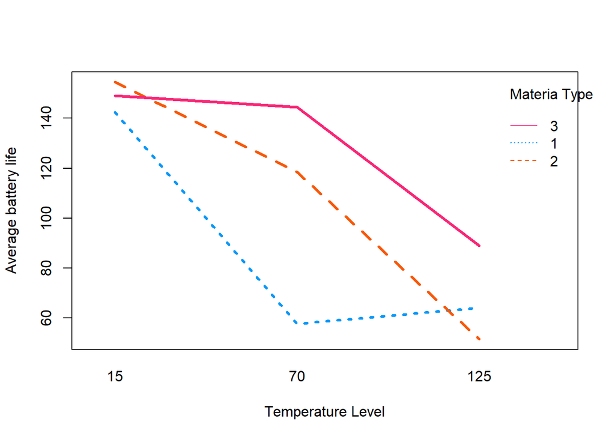

```r
# plot the interaction curve
# first convert the character variables to factors
df <- data.frame(Values, factor(Material_type), factor(Battery_data$Temp, levels = c(15,70,125)))

# plot
interaction.plot(
  x.factor = df$factor.Battery_data.Temp..levels...c.15..70..125..,
  trace.factor = df$factor.Material_type.,
  response = df$Values,
  fun = median,
  ylab = "Average battery life",
  xlab = "Temperature Level",
  trace.label = "Materia Type",
  col = c("#0198f9","#f95801","#f92676"),
  lwd = 3
)
```

- For material type 1, increase in temperature from 15 to 70 reduces the average battery life steadily from 140 to about 58. Further increase in temperature from 70 to 125 slightly increases the average battery life from 58 to about 62.
- For material type 2, increase in temperature from 15 all the way to 125 reduces the average battery life from about 155 to 50.
- For material type 3, increase in temperature from 15 to 70 has a very little effect on the average battery life. Further increase in temperature from 70 to 125 reduces the average battery life from about 150 to 90.

I can say that the best combination that guarantees a longer average battery life are; a temperature of 15 and material type 2.

```r
# post-hoc multiple range test using Tukey's HSD test
TukeyHSD(BattModel)
```

```
##   Tukey multiple comparisons of means
##     95% family-wise confidence level
##
## Fit: aov(formula = Values ~ Material_type * Temp, data = Battery_data)
##
## $Material_type
##         diff       lwr      upr     p adj
## 2-1 25.16667 -1.135677 51.46901 0.0627571
## 3-1 41.91667 15.614323 68.21901 0.0014162
## 3-2 16.75000 -9.552344 43.05234 0.2717815
##
## $Temp
##             diff       lwr       upr     p adj
## 15-125  80.66667  54.36432 106.96901 0.0000001
## 70-125  43.41667  17.11432  69.71901 0.0009787
## 70-15  -37.25000 -63.55234 -10.94766 0.0043788
##
## $`Material_type:Temp`
##               diff         lwr       upr     p adj
## 2:125-1:125  -8.00  -69.823184  53.82318 0.9999508
## 3:125-1:125  28.00  -33.823184  89.82318 0.8347331
## 1:15-1:125   77.25   15.426816 139.07318 0.0067471
## 2:15-1:125   98.25   36.426816 160.07318 0.0003574
## 3:15-1:125   86.50   24.676816 148.32318 0.0018765
## 1:70-1:125   -0.25  -62.073184  61.57318 1.0000000
## 2:70-1:125   62.25    0.426816 124.07318 0.0474675
## 3:70-1:125   88.25   26.426816 150.07318 0.0014679
## 3:125-2:125  36.00  -25.823184  97.82318 0.5819453
## 1:15-2:125   85.25   23.426816 147.07318 0.0022351
## 2:15-2:125  106.25   44.426816 168.07318 0.0001152
## 3:15-2:125   94.50   32.676816 156.32318 0.0006078
## 1:70-2:125    7.75  -54.073184  69.57318 0.9999614
## 2:70-2:125   70.25    8.426816 132.07318 0.0172076
## 3:70-2:125   96.25   34.426816 158.07318 0.0004744
## 1:15-3:125   49.25  -12.573184 111.07318 0.2016535
## 2:15-3:125   70.25    8.426816 132.07318 0.0172076
## 3:15-3:125   58.50   -3.323184 120.32318 0.0742711
## 1:70-3:125  -28.25  -90.073184  33.57318 0.8281938
## 2:70-3:125   34.25  -27.573184  96.07318 0.6420441
## 3:70-3:125   60.25   -1.573184 122.07318 0.0604247
## 2:15-1:15    21.00  -40.823184  82.82318 0.9616404
## 3:15-1:15     9.25  -52.573184  71.07318 0.9998527
## 1:70-1:15   -77.50 -139.323184 -15.67682 0.0065212
## 2:70-1:15   -15.00  -76.823184  46.82318 0.9953182
## 3:70-1:15    11.00  -50.823184  72.82318 0.9994703
## 3:15-2:15   -11.75  -73.573184  50.07318 0.9991463
## 1:70-2:15   -98.50 -160.323184 -36.67682 0.0003449
## 2:70-2:15   -36.00  -97.823184  25.82318 0.5819453
## 3:70-2:15   -10.00  -71.823184  51.82318 0.9997369
## 1:70-3:15   -86.75 -148.573184 -24.92682 0.0018119
## 2:70-3:15   -24.25  -86.073184  37.57318 0.9165175
## 3:70-3:15     1.75  -60.073184  63.57318 1.0000000
## 2:70-1:70    62.50    0.676816 124.32318 0.0460388
## 3:70-1:70    88.50   26.676816 150.32318 0.0014173
## 3:70-2:70    26.00  -35.823184  87.82318 0.8822881
```

- There are significant differences between material types 3&1.
- There is no significant difference between material types 1&2 and 2&3.
- There are significant differences between all the 3 temperature levels.
- And just as I saw from the interaction plot, material type 2 at temperature 15 vs material type 2 at temperature 125 has the smallest p-value, hence is highly significant. This implies that using material type 2 at temperature 15 produces batteries with the best life span while using material type 2 at temperature 125 produces batteries with the shortest life span.

```r
## Assessing the effects of reactant and catalyst quantities on yield conversion
# 2 by 2 design, replicated 3 times

# create the data
Reactant <- rep(c("low","high"), times = 6)
Catalyst <- rep(c("low","low","high","high"), times = 3)
Replication <- rep(c("1","2","3"), each = 4)
YieldConvertion <- c(28,36,18,31,25,32,19,30,27,32,23,29)
ChemicalData <- data.frame(Reactant, Catalyst, Replication, YieldConvertion)
```

```r
# carry out ANOVA using CRD
ChemModel <- aov(YieldConvertion ~ Reactant * Catalyst, data = ChemicalData)
# model summary
summary(ChemModel)
```

```
##                   Df Sum Sq Mean Sq F value   Pr(>F)
## Reactant           1 208.33  208.33  53.191 8.44e-05 ***
## Catalyst           1  75.00   75.00  19.149  0.00236 **
## Reactant:Catalyst  1   8.33    8.33   2.128  0.18278
## Residuals          8  31.33    3.92
## ---
## Signif. codes:  0 '***' 0.001 '**' 0.01 '*' 0.05 '.' 0.1 ' ' 1
```

- The main effect of Reactant is statistically significant and large (F(1, 8) = 53.19, p < .001)
- The main effect of Catalyst is also statistically significant and large (F(1, 8) = 19.15, p = 0.002)
- The interaction between Reactant and Catalyst is not statistically significant (F(1, 8) = 2.13, p = 0.183)

```r
# carry out ANOVA using RBD
ChemModel_2 <- aov(YieldConvertion ~ Replication + Reactant * Catalyst, data = ChemicalData)
# model summary
summary(ChemModel_2)
```

```
##                   Df Sum Sq Mean Sq F value   Pr(>F)
## Replication        2   6.50    3.25   0.785 0.497835
## Reactant           1 208.33  208.33  50.336 0.000394 ***
## Catalyst           1  75.00   75.00  18.121 0.005340 **
## Reactant:Catalyst  1   8.33    8.33   2.013 0.205710
## Residuals          6  24.83    4.14
## ---
## Signif. codes:  0 '***' 0.001 '**' 0.01 '*' 0.05 '.' 0.1 ' ' 1
```

- I used Replications as blocks and they don’t differ significantly at 5% level of significance (Of course replications aren’t suppose to differ). Replications are used to attain precision.
- The main effect of Reactant is statistically significant and large (F(1,6) = 50.34, p < .001).
- The main effect of Catalyst is also statistically significant and large (F(1,6) = 18.12, p = 0.005).
- The interaction between Reactant and Catalyst is not statistically significant (F(1, 6) = 2.01, p = 0.206).

```r
# post-hoc multiple range test using Tukey's HSD test
TukeyHSD(ChemModel_2)
```

```
##   Tukey multiple comparisons of means
##     95% family-wise confidence level
##
## Fit: aov(formula = YieldConvertion ~ Replication + Reactant * Catalyst, data = ChemicalData)
##
## $Replication
##      diff       lwr      upr     p adj
## 2-1 -1.75 -6.163886 2.663886 0.4869312
## 3-1 -0.50 -4.913886 3.913886 0.9362682
## 3-2  1.25 -3.163886 5.663886 0.6776402
##
## $Reactant
##               diff       lwr       upr     p adj
## low-high -8.333333 -11.20742 -5.459249 0.0003936
##
## $Catalyst
##          diff      lwr      upr     p adj
## low-high    5 2.125915 7.874085 0.0053397
##
## $`Reactant:Catalyst`
##                          diff         lwr        upr     p adj
## low:high-high:high -10.000000 -15.7502551 -4.2497449 0.0038437
## high:low-high:high   3.333333  -2.4169217  9.0835884 0.2827601
## low:low-high:high   -3.333333  -9.0835884  2.4169217 0.2827601
## high:low-low:high   13.333333   7.5830783 19.0835884 0.0008271
## low:low-low:high     6.666667   0.9164116 12.4169217 0.0269114
## low:low-high:low    -6.666667 -12.4169217 -0.9164116 0.0269114
```

- The Tukey’s HSD test confirms that the replications are not statistically different and this is good.
- There are significant differences between the levels of reactant and catalyst.
- All the interaction effects are statistically significant, except (high Reactant amount at low Catalyst amount vs high Reactant amount at high Catalyst amount) and (low Reactant amount at low Catalyst amount vs high Reactant amount at high Catalyst amount).

```r
## Assess if there is a statistical difference in the quantity of Dirt removed when two detergents are used, each at different temperatures

# Another 2 by 2 factorial design

# first create the data
Temperature <- rep(c("warm","hot"), each = 5, times = 2)
Detergent <- rep(c("X","Y"), each = 10)
Dirt_removed <- c(14,16,15,12,17,18,19,17,19,20,
                  17,19,20,17,22,21,20,18,22,23)
DirtRemovalData <- data.frame(Detergent, Temperature, Dirt_removed)
```

```r
# carry out ANOVA
DirtModel <- aov(Dirt_removed ~ Detergent * Temperature, data = DirtRemovalData)
# model summary
summary(DirtModel)
```

```
##                       Df Sum Sq Mean Sq F value  Pr(>F)
## Detergent              1   51.2    51.2  15.515 0.00117 **
## Temperature            1   39.2    39.2  11.879 0.00332 **
## Detergent:Temperature  1    5.0     5.0   1.515 0.23614
## Residuals             16   52.8     3.3
## ---
## Signif. codes:  0 '***' 0.001 '**' 0.01 '*' 0.05 '.' 0.1 ' ' 1
```

- The main effect of Detergent is statistically significant and large (F(1,16) = 15.52, p = 0.001).
- The main effect of Temperature is statistically significant and large (F(1, 16) = 11.88, p = 0.003).
- The interaction between Detergent and Temperature is not statistically significant (F(1,16) = 1.52, p = 0.236).

```r
# post-hoc multiple range test using Tukey's HSD test
TukeyHSD(DirtModel)
```

```
##   Tukey multiple comparisons of means
##     95% family-wise confidence level
##
## Fit: aov(formula = Dirt_removed ~ Detergent * Temperature, data = DirtRemovalData)
##
## $Detergent
##     diff      lwr      upr     p adj
## Y-X  3.2 1.477781 4.922219 0.0011735
##
## $Temperature
##          diff       lwr       upr     p adj
## warm-hot -2.8 -4.522219 -1.077781 0.0033176
##
## $`Detergent:Temperature`
##               diff        lwr        upr     p adj
## Y:hot-X:hot    2.2 -1.0870615  5.4870615 0.2609184
## X:warm-X:hot  -3.8 -7.0870615 -0.5129385 0.0208206
## Y:warm-X:hot   0.4 -2.8870615  3.6870615 0.9849705
## X:warm-Y:hot  -6.0 -9.2870615 -2.7129385 0.0004398
## Y:warm-Y:hot  -1.8 -5.0870615  1.4870615 0.4238569
## Y:warm-X:warm  4.2  0.9129385  7.4870615 0.0103215
```

```r
## Ultra Filtration Experiment (2 by 2 replicated 4 times)

# first create a data frame with the factors and values
Additive <- rep(c("low","high"),each = 4, times = 2)
Time <- rep(c("1","3"), each = 8) # the no. of times additive was applied
Quantity <- c(69.6,71.5,70,69,91,93,93.2,87.2,80,81.6,83,84.3,92.3,93.4,
                 88.5,95.6)
UltraData <- data.frame(Additive, Time, Quantity)
```

```r
# carry out ANOVA
UltraFiltrationModel <- aov(Quantity ~ Additive * Time, data = UltraData)
summary(UltraFiltrationModel)
```

```
##               Df Sum Sq Mean Sq F value   Pr(>F)
## Additive       1  979.7   979.7  185.59 1.16e-08 ***
## Time           1  183.6   183.6   34.78 7.28e-05 ***
## Additive:Time  1  117.7   117.7   22.30 0.000495 ***
## Residuals     12   63.3     5.3
## ---
## Signif. codes:  0 '***' 0.001 '**' 0.01 '*' 0.05 '.' 0.1 ' ' 1
```

- The main effect of Additive is statistically significant and large (F(1,12) = 185.59, p < .001).
- The main effect of Time is statistically significant and large (F(1, 12) = 34.78, p < .001).
- The interaction between Additive and Time is statistically significant and large (F(1,12) = 22.30, p < .001).

```r
# post-hoc multiple range test using Tukey's HSD test
TukeyHSD(UltraFiltrationModel)
```

```
##   Tukey multiple comparisons of means
##     95% family-wise confidence level
##
## Fit: aov(formula = Quantity ~ Additive * Time, data = UltraData)
##
## $Additive
##            diff       lwr       upr p adj
## low-high -15.65 -18.15297 -13.14703     0
##
## $Time
##      diff      lwr      upr    p adj
## 3-1 6.775 4.272031 9.277969 7.28e-05
##
## $`Additive:Time`
##                  diff        lwr        upr     p adj
## low:1-high:1  -21.075 -25.898322 -16.251678 0.0000001
## high:3-high:1   1.350  -3.473322   6.173322 0.8388386
## low:3-high:1   -8.875 -13.698322  -4.051678 0.0007206
## high:3-low:1   22.425  17.601678  27.248322 0.0000001
## low:3-low:1    12.200   7.376678  17.023322 0.0000368
## low:3-high:3  -10.225 -15.048322  -5.401678 0.0002021
```

- There are significant differences between the amount of additive applied and the number of times the additive was applied with regards to the quantity of ultra-filtration achieved.
- High amount of additive when applied 3 times and also when applied only once, doesn’t result in a significant difference in quantity of ultra-filtration achieved.
- All the remaining interaction effects differ significantly with regards to the quantity of ultra-filtration achieved.

# 5. Split-Plot Design

```r
## Assess if pulp preparation method and different temperature levels have significant effect on the yield of paper production

## The experiment was conducted in a split-plot design

# first create the data frame

# create a vector containing block labels
Block <- rep(c("1","2","3"), each = 12)
# create a vector containing the different types of pulp
Pulp <- rep(c("1","2","3"), times = 12)
# create a vector containing the different temperature levels
Tmp <- rep(c("200","225","250","275"), each = 3, times = 3)
# create a vector containing the paper yields
paper_yield <- c(30,34,29,35,41,26,37,38,33,36,42,36,28,31,31,32,36,30,
                 40,42,32,41,40,40,31,35,32,37,40,34,41,39,39,40,44,45)

# combine the vectors into a data frame
PaperData <- data.frame(Block, Pulp, Tmp, paper_yield)
```

```r
# carry out ANOVA
PaperModel <- sp.plot(block = Block, pplot = Pulp, splot = Tmp, Y = paper_yield)
```

```
##
## ANALYSIS SPLIT PLOT:  paper_yield
## Class level information
##
## Pulp     :  1 2 3
## Tmp  :  200 225 250 275
## Block    :  1 2 3
##
## Number of observations:  36
##
## Analysis of Variance Table
##
## Response: paper_yield
##          Df Sum Sq Mean Sq F value    Pr(>F)
## Block     2  77.56  38.778  9.7622  0.001345 **
## Pulp      2 128.39  64.194  7.0781  0.048537 *
## Ea        4  36.28   9.069
## Tmp       3 434.08 144.694 36.4266 7.449e-08 ***
## Pulp:Tmp  6  75.17  12.528  3.1538  0.027109 *
## Eb       18  71.50   3.972
## ---
## Signif. codes:  0 '***' 0.001 '**' 0.01 '*' 0.05 '.' 0.1 ' ' 1
##
## cv(a) = 8.4 %, cv(b) = 5.5 %, Mean = 36.02778
```

```r
# have a model summary
summary(PaperModel)
```

```
##       Length Class  Mode
## ANOVA 5      anova  list
## gl.a  1      -none- numeric
## gl.b  1      -none- numeric
## Ea    1      -none- numeric
## Eb    1      -none- numeric
```

```r
# carry out post-hoc multiple comparison tests on treatments using LSD test

# specify the first error degrees of freedom
Error_df_a <- PaperModel$gl.a
Error_df_a
```

```
## [1] 4
```

```r
# specify the second error degrees of freedom
Error_df_b <- PaperModel$gl.b
Error_df_b
```

```
## [1] 18
```

```r
# specify the first mean square error
MSE_a <- PaperModel$Ea
MSE_a
```

```
## [1] 9.069444
```

```r
# specify the second mean square error
MSE_b <- PaperModel$Eb
MSE_b
```

```
## [1] 3.972222
```

```r
# test for difference in means between the three Pulp preparation methods
lsd1 <- LSD.test(y = paper_yield,
                 trt = Pulp,
                 DFerror = Error_df_a,
                 MSerror = MSE_a,
                 alpha = 0.05,
                 p.adj = "bonferroni",
                 group = TRUE,
                 console = TRUE)
```

```
##
## Study: paper_yield ~ Pulp
##
## LSD t Test for paper_yield
## P value adjustment method: bonferroni
##
## Mean Square Error:  9.069444
##
## Pulp,  means and individual ( 95 %) CI
##
##   paper_yield      std  r        se      LCL      UCL Min Max   Q25  Q50   Q75
## 1    35.66667 4.519319 12 0.8693601 33.25294 38.08040  28  41 31.75 36.5 40.00
## 2    38.50000 3.825750 12 0.8693601 36.08627 40.91373  31  44 35.75 39.5 41.25
## 3    33.91667 5.299371 12 0.8693601 31.50294 36.33040  26  45 30.75 32.5 36.75
##
## Alpha: 0.05 ; DF Error: 4
## Critical Value of t: 3.960786
##
## Minimum Significant Difference: 4.869632
##
## Treatments with the same letter are not significantly different.
##
##   paper_yield groups
## 2    38.50000      a
## 1    35.66667      a
## 3    33.91667      a
```

```r
lsd1
```

```
## $statistics
##    MSerror Df     Mean       CV  t.value      MSD
##   9.069444  4 36.02778 8.358972 3.960786 4.869632
##
## $parameters
##         test  p.ajusted name.t ntr alpha
##   Fisher-LSD bonferroni   Pulp   3  0.05
##
## $means
##   paper_yield      std  r        se      LCL      UCL Min Max   Q25  Q50   Q75
## 1    35.66667 4.519319 12 0.8693601 33.25294 38.08040  28  41 31.75 36.5 40.00
## 2    38.50000 3.825750 12 0.8693601 36.08627 40.91373  31  44 35.75 39.5 41.25
## 3    33.91667 5.299371 12 0.8693601 31.50294 36.33040  26  45 30.75 32.5 36.75
##
## $comparison
## NULL
##
## $groups
##   paper_yield groups
## 2    38.50000      a
## 1    35.66667      a
## 3    33.91667      a
##
## attr(,"class")
## [1] "group"
```

The three types of Pulp preparation methods do not differ significantly with regards to paper yield.

```r
# test for difference in mean between the three Temperature levels used
lsd2 <- LSD.test(y = paper_yield,
                 trt = Tmp,
                 DFerror = Error_df_b,
                 MSerror = MSE_b,
                 alpha = 0.05,
                 p.adj = "bonferroni",
                 group = TRUE,
                 console = TRUE)
```

```
##
## Study: paper_yield ~ Tmp
##
## LSD t Test for paper_yield
## P value adjustment method: bonferroni
##
## Mean Square Error:  3.972222
##
## Tmp,  means and individual ( 95 %) CI
##
##     paper_yield      std r        se      LCL      UCL Min Max Q25 Q50 Q75
## 200    31.22222 2.223611 9 0.6643478 29.82648 32.61797  28  35  30  31  32
## 225    34.55556 4.746344 9 0.6643478 33.15981 35.95130  26  41  32  35  37
## 250    37.88889 3.407508 9 0.6643478 36.49315 39.28463  32  42  37  39  40
## 275    40.44444 3.086710 9 0.6643478 39.04870 41.84019  36  45  40  40  42
##
## Alpha: 0.05 ; DF Error: 18
## Critical Value of t: 2.962735
##
## Minimum Significant Difference: 2.783577
##
## Treatments with the same letter are not significantly different.
##
##     paper_yield groups
## 275    40.44444      a
## 250    37.88889      a
## 225    34.55556      b
## 200    31.22222      c
```

```r
lsd2
```

```
## $statistics
##    MSerror Df     Mean       CV  t.value      MSD
##   3.972222 18 36.02778 5.531963 2.962735 2.783577
##
## $parameters
##         test  p.ajusted name.t ntr alpha
##   Fisher-LSD bonferroni    Tmp   4  0.05
##
## $means
##     paper_yield      std r        se      LCL      UCL Min Max Q25 Q50 Q75
## 200    31.22222 2.223611 9 0.6643478 29.82648 32.61797  28  35  30  31  32
## 225    34.55556 4.746344 9 0.6643478 33.15981 35.95130  26  41  32  35  37
## 250    37.88889 3.407508 9 0.6643478 36.49315 39.28463  32  42  37  39  40
## 275    40.44444 3.086710 9 0.6643478 39.04870 41.84019  36  45  40  40  42
##
## $comparison
## NULL
##
## $groups
##     paper_yield groups
## 275    40.44444      a
## 250    37.88889      a
## 225    34.55556      b
## 200    31.22222      c
##
## attr(,"class")
## [1] "group"
```

- Temperature levels 250 and 275 have almost the same effect on paper yield, but are significantly different from temperature levels 200 and 225.

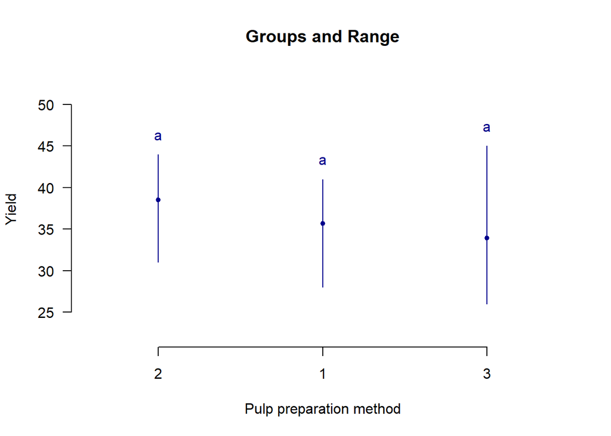

```r
# plot Yield variation by Pulp preparation method
plot(lsd1,
     xlab = "Pulp preparation method",
     ylab = "Yield",
     las = 1
     )
```

There is no difference in yield variations based on the three pulp preparation methods.

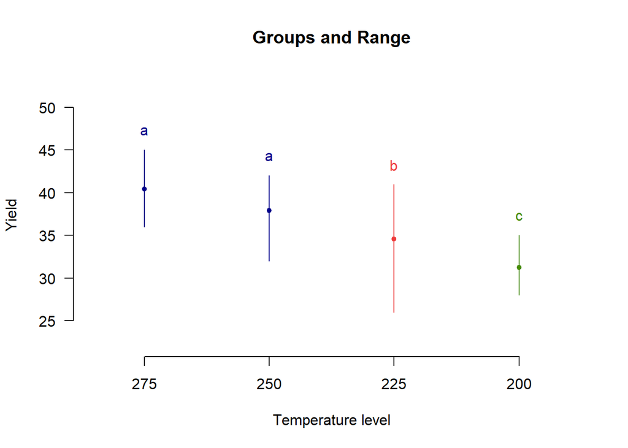

```r
# plot Yield variation by Temperature level
plot(lsd2,
     xlab = "Temperature level",
     ylab = "Yield",
     las = 1
     )
```

Temperature levels 250 and 275 have almost the same effect on paper yield, but are significantly different from temperature levels 200 and 225.